# spins

Chad Worley

December 2, 2019

## Introduction

A spinner is one of the most iconic randomizing devices. Versions of spinners show up in television shows, such as *Wheel of Fortune* and *The Price is Right*. Spinners are also featured in a number of at-home games, such as *Twister* and *The Game of Life*.

As a Statistics teacher, I am interested in spinners as a way of displaying and discussing probability distributions and random variables. Spinners can depict categorical, discrete, and continuous random variables. It is easy to understand that larger areas have higher probabilities. I personally believe (without support) that a spinner is easier to understand than a probability density.

Sometimes I find it helpful to display two different distributions, like a standard normal and a standard uniform. This depiction shows the correspondence between standard scores and percentiles. I think it is pretty easy to understand, by looking at the spinner below, that $P(0<Z<1) \approx 0.841-0.5$.

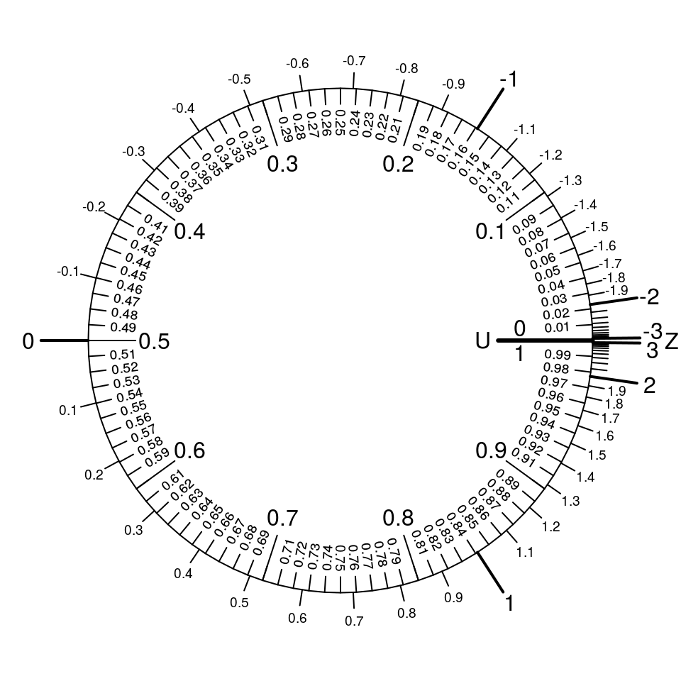

A potential drawback of spinners as metaphors for randomness is a spinner’s inherently deterministic behaviour. The initial velocity determines the final position, and (as far as I know) small variations in initial velocity do not have substantially different final positions (as is seen in more [chaotic](https://en.wikipedia.org/wiki/Chaos_theory) nonlinear systems like a [double pendulum](https://en.wikipedia.org/wiki/Double_pendulum)). However, a spinner with less friction will have more variation in final position with subtle differences in initial velocity.

The randomness of a spinner depends on the human’s inaccuracy in controlling the initial velocity. I was interested in how well I could control a spinner. Before any trials, I assumed I would be able to reliably spin the spinner $720^\circ \pm 45^\circ$.

## Method

All spins used a plastic spinner meant for educational purposes. It has two parts, a base and the 4-inch arrow. The arrow is weighted equally on either side of the base (about 2 inches on either side). The friction is low enough that getting 10 complete rotations is quite easy. The middles of the arrow and base are hollow, allowing precise alignment of the arrow in the middle of the demarcated circle.

The demarcated circle was designed such that random spins would produce a standard normal distribution. Instead of having one rotation mapped to the interval [0,1], each half rotation was mapped to [0,1] such that no discontinuities exist. The idea is that the 1 (or 0) is the target, and deviation from the target in either direction is measured. By repeatedly landing near the target, the sample mean should be above (or below) the expected value of random spins, which is of course 0.5.

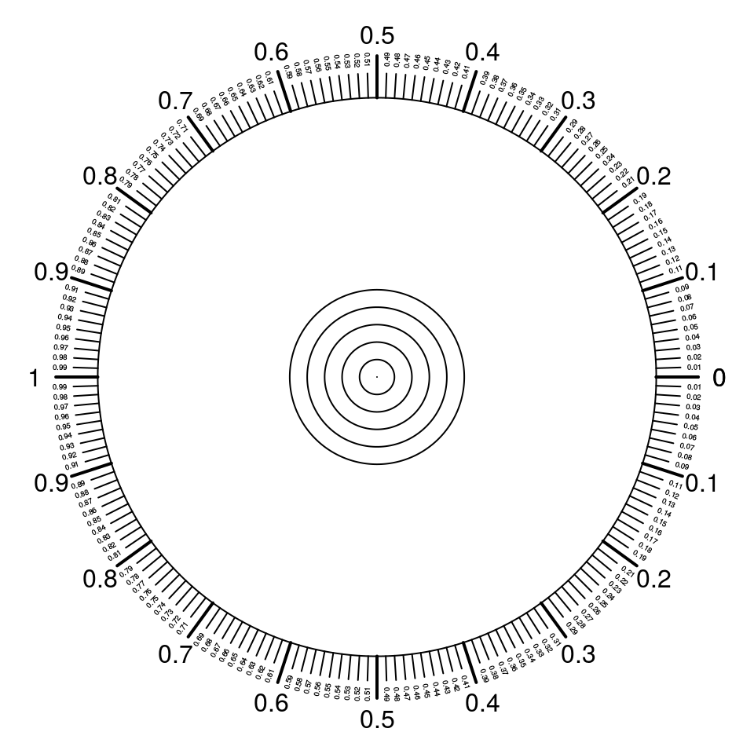

```r
par(mar=c(0,0,0,0))
plot(0,0,type='n',axes=F,ann=F,xlim=c(-1,1),ylim=c(-1,1))
thetas = seq(0,2*pi,length.out=2001)
polygon(0.8*cos(thetas),0.8*sin(thetas))
for(p in seq(0,0.25,0.05)){
  polygon(p*cos(thetas),p*sin(thetas))
}

for(theta in seq(0,2*pi,length.out=201)){
  lines(c(0.87*cos(theta),0.8*cos(theta)),c(0.87*sin(theta),0.8*sin(theta)))
  }

for(th in seq(0,2*pi,length.out=21)){
  lines(c(0.92*cos(th),0.8*cos(th)),c(0.92*sin(th),0.8*sin(th)),lwd=2)
  u = 1-abs(pi-th)/pi
  text(0.98*cos(th),0.98*sin(th),u)
}

for(i in 0:100){
  if(i%%10 != 0){
    text(cos(i/100*pi)*0.91,sin(i/100*pi)*0.91,i/100,cex=0.3,srt=((i/100*180)+90)%%180-90)
    text(cos(i/100*pi)*0.91,-sin(i/100*pi)*0.91,i/100,cex=0.3,srt=-((i/100*180)+90)%%180-90)
  }
}
```

## Data

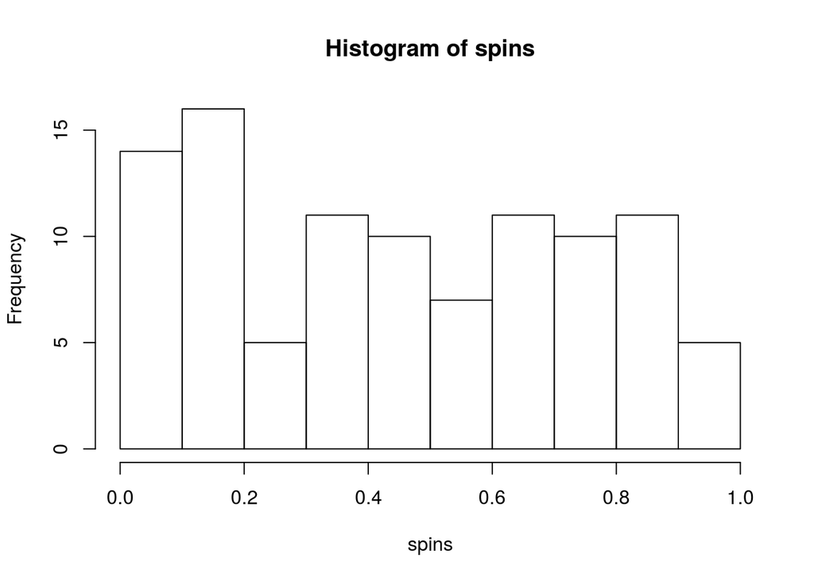

The mean is 0.45582. The sample size is 100. The standard error is 0.0288675. The standard score is -1.5304401. The one-tail $p$-value is 0.0629539 or 0.9370461. The two-tail $p$-value is 0.1259078.